# Ecological Models and Data Analysis – Chapter 2 — Ecological Models and Data Analysis

## Ecological Models and Data Analysis

Chapter 2 · Lecture

Probability Distributions

## Overview of the lecture

1. **Discrete random variables:** what can we count, and how probable is it?
2. **The four faces:** how do we calculate with a distribution?
3. **Continuous random variables:** what is a probability density?
4. **Joint distributions:** when are observations independent?
5. **Expectations:** what are the mean and the variance of a distribution?
6. **Choosing a distribution:** which distribution for which data?
7. **The practical:** what comes next?

## Where we are: the modelling cycle

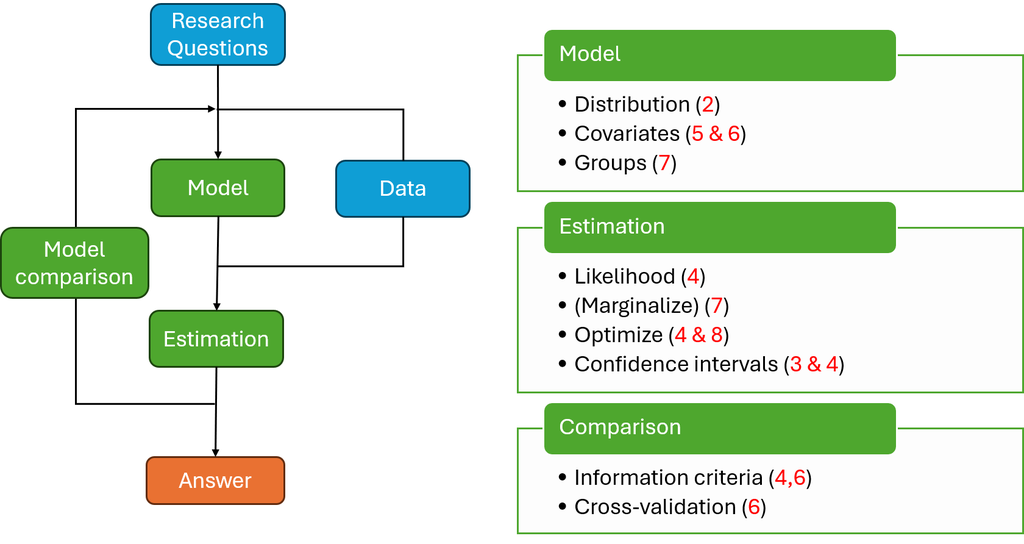

Red numbers: chapters of the course. This lecture: the distribution (2) in the model box.

## Random variables and support

**Random variable:** a quantity whose value is uncertain before we observe it.

Four seeds per quadrat, $X$ = surviving seeds: $X \in \{0, 1, 2, 3, 4\}$.

**Support:** the set of values that the random variable can take.

- **Finite:** 0 to 4 seeds.
- **Countably infinite:** insects in a trap, $\{0, 1, 2, \ldots\}$.
- **$X$ and $x$:** the random variable and an observed value.

## Probabilities of counts

| $x$ | $P(X = x)$ |
| --- | --- |
| 0 | 0.05 |
| 1 | 0.15 |
| 2 | 0.30 |
| 3 | 0.30 |
| 4 | 0.20 |

- Probabilities between 0 and 1
- Probabilities add up to 1
- Probability set = sum of individual probabilities

At least three seeds: $P(X \geq 3) = P(X = 3) + P(X = 4) = 0.50$

$$\sum_{\forall x} P(X = x) = 1$$

What is $P(X \leq 1)$?

## What do these probabilities mean?

### Aleatoric - Frequentist

- Relative frequency across replications.
- Observation error, process variation, parameter estimates.

### Epistemic - Bayesian

- How certain are we about any unobserved value?
- Predictions, parameter estimates, latent variables.

This course: probability as relative frequency (frequentist).

## The Binomial distribution - Probability mass

$$P(X = x) = \binom{n}{x} p^x (1 - p)^{n - x}$$

- **Maximum number of items:** $n$ seeds.
- **Two outcomes per item:** survives (1) or not (0).
- **Same probability per item:** $p$ for every individual seed.

$n = 4$, $p = 0.4$: $P(X = 2) = 6 \times 0.16 \times 0.36 \approx 0.35$

## The four faces of a distribution

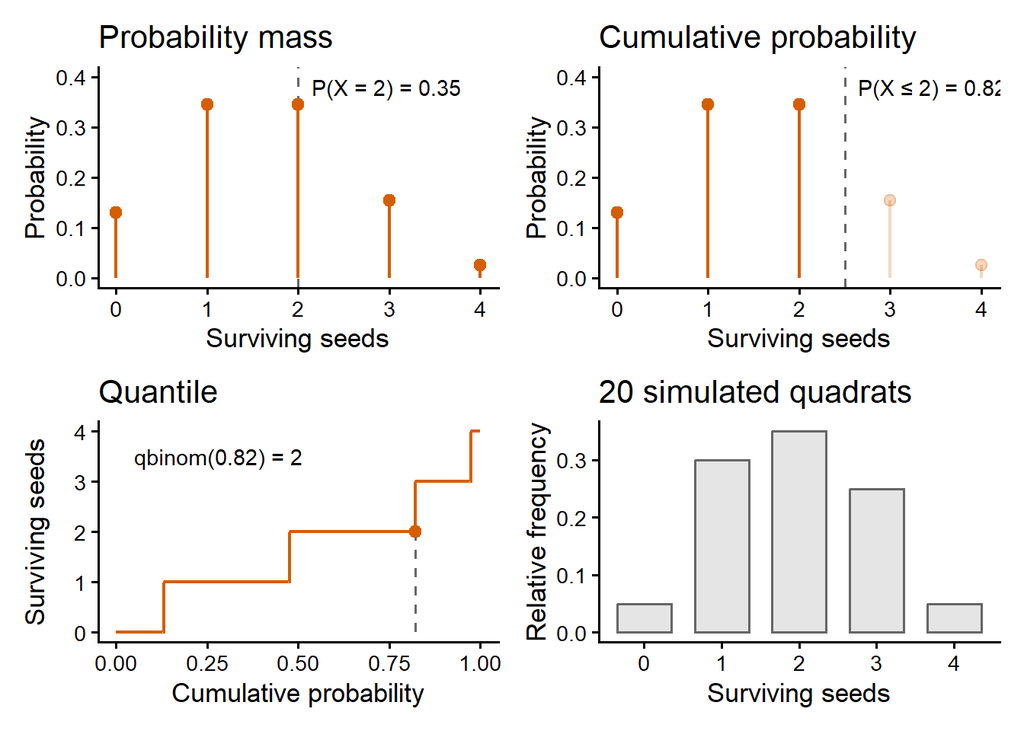

- **Mass:** $P(X = x)$.
- **Cumulative probability:** $P(X \leq x)$.
- **Quantile:** the inverse of cumulative probability.
- **Random sampler:** simulate possible samples.

Vermillion: the model. Grey: 20 simulated quadrats. Dashed: the cutoff at 2 seeds.

## Cumulative probability and quantiles

**Cumulative probability:** $F_X(x) = P(X \leq x)$

**Quantile:** $q_\alpha = \min\{x : F_X(x) \geq \alpha\}$

Seeds: $F_X(2) \approx 0.82$; the median $q_{0.5} = 2$.

Quantiles return as confidence intervals (Chapter 3).

## The four faces in R

```r
# size = n, prob = p in formula for Binomial
seed_survival_probability = 0.4
seed_count  = 4
dbinom(x = 2,   size = seed_count, prob = seed_survival_probability)
pbinom(q = 2,   size = seed_count, prob = seed_survival_probability)
qbinom(p = 0.5, size = seed_count, prob = seed_survival_probability)
rbinom(n = 10,  size = seed_count, prob = seed_survival_probability)
```

**Name:** prefix (`d`, `p`, `q`, `r`) + distribution (`binom`).

**Arguments:** first `x`, `q`, `p` or `n`, then the parameters.

## Live demo: discrete distributions

1. Load the distribution functions.
2. The four faces of the Binomial.
3. Check $P(X = 2)$ by hand and in R.
4. Simulate with a seed; Practice 1 (orchid fruit set).

**Follow along:** Chapter 2, *The four faces of a distribution*.

## Continuous random variables

**Continuous random variable:** can take any value within an interval.

123 Gentoo penguins: flipper length (mm).

- Between 217 and 218 mm: infinitely many lengths.
- Records rounded to the nearest mm.

A flipper recorded as 221 mm: which lengths could it be? Is $P(X = 221) > 0$?

## Probability density

[figure not shown]

$$P(a < X \leq b) = \int_a^b f_X(x)\,dx$$

- **Probability:** area under the curve.
- **Density:** $f_X(x) \geq 0$, total area 1.
- **Endpoints:** do not matter.

## The Normal distribution - Probability density

$$f_X(x) = \frac{1}{\sigma\sqrt{2\pi}} \exp\left[-\frac{(x - \mu)^2}{2\sigma^2}\right]$$

- **$\mu$:** the mean, sets the centre.
- **$\sigma$:** the standard deviation, sets the spread.

Flipper length: $\mu = 217$ mm, $\sigma = 6.5$ mm (rounded values that describe the 123 penguins).

## Mass and density

### Discrete

- `d*`: a probability, $P(X = x)$.
- Sets of values: sums.
- At most 1.

### Continuous

- `d*`: a density, in 1/mm.
- Intervals: integrals.
- Can exceed 1.

Density at 217 mm: 0.0614/mm, or 0.614/cm.

A density is a probability per unit of $X$, not the probability of a value.

Can a density be larger than 1?

## The four faces of the Normal distribution

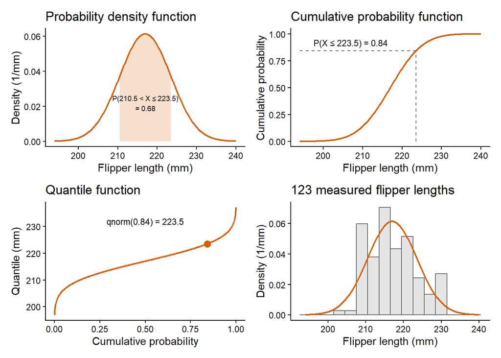

- **Density:** probability as area.
- **Cumulative probability:** smooth.
- **Quantile:** the inverse of cumulative probability.
- **Random sampler:** simulate possible samples.

Vermillion: the model. Grey: the measured flipper lengths.

## Intervals and tails in R

$$P(a < X \leq b) = F_X(b) - F_X(a)$$

```r
# Between 210.5 and 223.5 mm: about 0.68
pnorm(q = 223.5, mean = 217, sd = 6.5) - pnorm(q = 210.5, mean = 217, sd = 6.5)
# Longer than 230 mm: about 0.02
pnorm(q = 230, mean = 217, sd = 6.5, lower.tail = FALSE)
# 0.95 quantile: about 227.7 mm
qnorm(p = 0.95, mean = 217, sd = 6.5)
```

## Discussion: `d`, `p`, `q` or `r`?

1. The probability that exactly two of four seeds survive.
2. The probability that a flipper is between 210 and 220 mm.
3. The length below which 95% of flippers fall.
4. Survival counts for 20 hypothetical quadrats.

`d` · `p` · `q` · `r`

**1 minute:** decide with a neighbour.

## Live demo: continuous distributions

1. Load the penguin data.
2. The density at 217 mm, in mm and in cm.
3. Intervals, tails and quantiles.
4. Practice 3 (a flipper length threshold).

**Follow along:** Chapter 2, *Mass and density* and *The four faces of a continuous distribution*.

## Joint and marginal distributions

**Joint distribution:** a probability for every combination of values.

| Two seeds | $x_1 = 0$ | $x_1 = 1$ | Marginal $X_2$ |
| --- | --- | --- | --- |
| $x_2 = 0$ | $P(0, 0)$ | $P(1, 0)$ | $P(X_2 = 0)$ |
| $x_2 = 1$ | $P(0, 1)$ | $P(1, 1)$ | $P(X_2 = 1)$ |
| Marginal $X_1$ | $P(X_1 = 0)$ | $P(X_1 = 1)$ | 1 |

**Marginal distribution:** add over a row or a column.

## Independence

$$P(X_1 = x_1, X_2 = x_2) = P(X_1 = x_1)\,P(X_2 = x_2)$$

| Two seeds | $x_1 = 0$ | $x_1 = 1$ | Marginal $X_2$ |
| --- | --- | --- | --- |
| $x_2 = 0$ | $0.4 \times 0.7 = 0.28$ | $0.6 \times 0.7 = 0.42$ | 0.70 |
| $x_2 = 1$ | $0.4 \times 0.3 = 0.12$ | $0.6 \times 0.3 = 0.18$ | 0.30 |
| Marginal $X_1$ | 0.40 | 0.60 | 1.00 |

Independence is an assumption of the model.

Why might two seeds not be independent?

## Continuous joint distribution

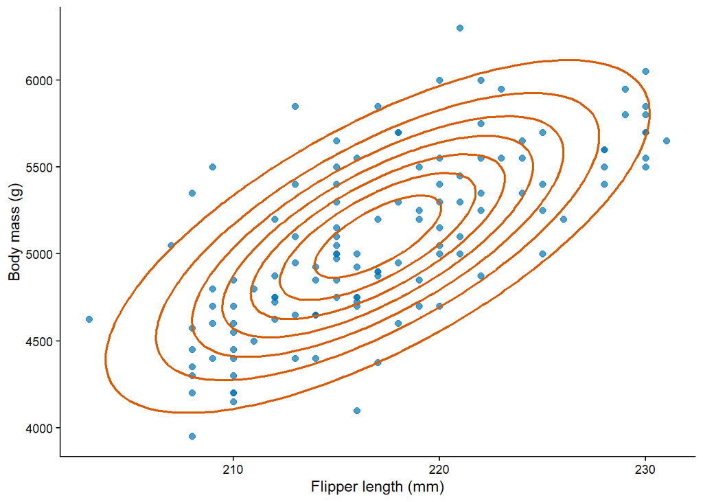

- **Contours:** equal joint density.
- **Multivariate distribution:** marginal + dependence structure.
- **Parameters:** mean, std devs, corr
- **Tilted:** correlation of 0.7.
- **Probability above mean:** 0.25 if independent, about 0.37 here.

Blue: the 123 penguins. Vermillion: contours of the model (Multivariate Normal).

## Independent and identically distributed

**i.i.d.:** independent and identically distributed.

- **Identically distributed:** the same distribution.
- **Independent:** a separate assumption.

| Two seeds | $x_1 = 0$ | $x_1 = 1$ | Marginal $X_2$ |
| --- | --- | --- | --- |
| $x_2 = 0$ | $0.7 \times 0.7 = 0.49$ | $0.7 \times 0.3 = 0.21$ | 0.7 |
| $x_2 = 1$ | $0.3 \times 0.7 = 0.21$ | $0.3 \times 0.3 = 0.09$ | 0.3 |
| Marginal $X_1$ | 0.7 | 0.3 | 1 |

The basis of estimation in Chapters 3 and 4.

## Discussion: joint, marginal or independent?

1. The body mass of a penguin, whatever its flipper length.
2. A flipper of 210 to 225 mm and a body mass above 5000 g.
3. The acorns of two oaks under the same weather.
4. Four visits to the same stream site.

Joint · Marginal · Independent · i.i.d.

**1 minute:** decide with a neighbour.

## Expectations and the mean

$$E[f(X)] = \sum_x f(x)\,P(X = x)$$

- **Expectation:** a probability-weighted average.
- **Mean:** $E[X]$, the expectation of $X$ itself.

Seed model ($n = 4$, $p = 0.4$): $E[X] = 1.6$ seeds, a count that no quadrat can have.

## Variance and standard deviation

$$\operatorname{Var}(X) = E[(X - E[X])^2]$$

- **Variance:** the expected squared distance from the mean.
- **Standard deviation:** $\sqrt{\operatorname{Var}(X)}$, in the units of $X$.

Flipper model: 42.25 mm², standard deviation 6.5 mm (the parameter $\sigma$).

Seed model: mean 1.6, variance 0.96 (not parameters).

## Choosing a distribution

### Discrete

- **Upper limit:** Binomial.
- **No upper limit:** Poisson, Negative Binomial.

### Continuous

- **Unconstrained:** Normal.
- **Positive:** LogNormal.
- **Constrained:** Beta.

No correct distribution, only plausible candidates: range of values, mean–variance relationship, fit to the data.

## Overdispersion

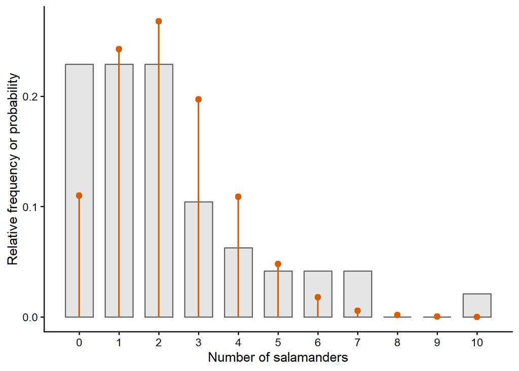

- **Poisson:** $E[X] = \operatorname{Var}(X) = \lambda$.
- **Dispersion ratio:** sample variance / sample mean.
- **Salamanders:** mean 2.21, variance 4.98, ratio about 2.3.

Grey: 48 salamander counts. Vermillion: Poisson with the same mean.

## Distributions for overdispersed counts

**Negative Binomial:** mean $\mu$, shape $k$.

$$\operatorname{Var}(X) = \mu + \frac{\mu^2}{k}$$

- **Small $k$:** more variance.
- **Large $k$:** close to the Poisson.

Why could the salamander counts be overdispersed?

## Live demo: expectations and overdispersion

1. Mean and variance of the seed model.
2. Mean and variance of the flipper model by integration.
3. The dispersion ratio of the salamander counts.
4. Practice 4 (fruit set on orchid plants).

**Follow along:** Chapter 2, *Expectations and central moments* and *Overdispersion*.

## Course roadmap: from distributions to estimates

| Chapter | Main question |
| --- | --- |
| **2. Probability distributions** | What can we observe, and how probable is it? |
| **3. From samples to estimates** | What does a sample tell us? |
| **4. Maximum likelihood estimation** | How do we estimate, and how uncertain are we? |

## The Chapter 2 R practical

- **Seedling survival and bill length:** worked examples.
- **Overdispersion:** insect counts by spray.
- **Negative Binomial:** quadrat counts.
- **LogNormal:** body mass.
- **Beta:** vegetation cover.

Read the supplement entries first. Try, then check.

## Summary and closing questions

- A distribution assigns probabilities to sets of values.
- Four faces: `d`, `p`, `q`, `r`.
- Mass is a probability; density is per unit of $X$.
- Independence and i.i.d. are assumptions.
- Mean and variance are expectations.
- Choose by the range of values and the mean–variance relationship.

Random variable · Distribution · Four faces · Density · Independence · Expectation · Overdispersion

**Closing questions**

1. Why is `dnorm()` at 217 mm not the probability of a 217 mm flipper?
2. A dispersion ratio of 2.3: what does it tell us, and what does it not?